# BDA_report

## 5.8 **社会认知与幸福感**

**探索社会公平（equity）与幸福感（happiness)的关系**

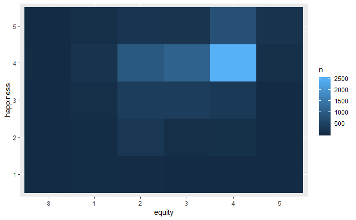

```r
#查看各社会公平认知水平下不同幸福感的人数分布

data%>%
  count(equity,happiness)%>%
  ggplot(mapping = aes(equity,happiness))+
  geom_tile(mapping = aes(fill=n))
```

- 由热度图可知，比较幸福（happiness=4）且认为社会比较公平（equity=4）的人人数最多。

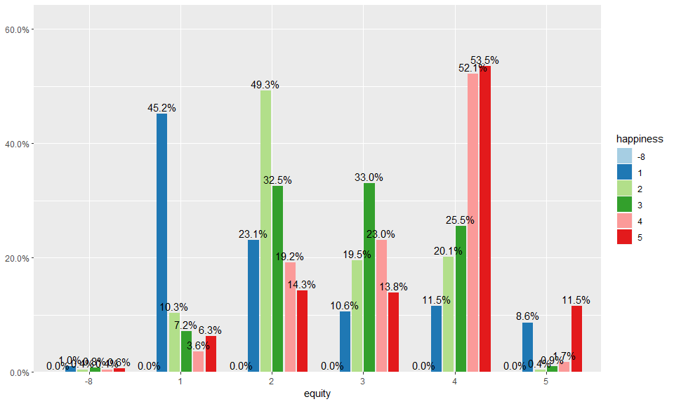

```r
sjPlot::sjp.xtab(data$equity,data$happiness,show.total = FALSE,show.prc = TRUE,show.n = FALSE)
```

- 由上图分析可知，非常不幸福的人中间认为社会完全不公平的占比最多为45.2%；非常幸福的人中间认为社会比较公平的占比最多为53.5%；从整体上看，认为社会比较公平且比较幸福的人占比最多。因此判断社会公平的建设有助于提高公民幸福感。

**探索个人观点与社会观点的一致性（view）与幸福感（happiness)的关系**

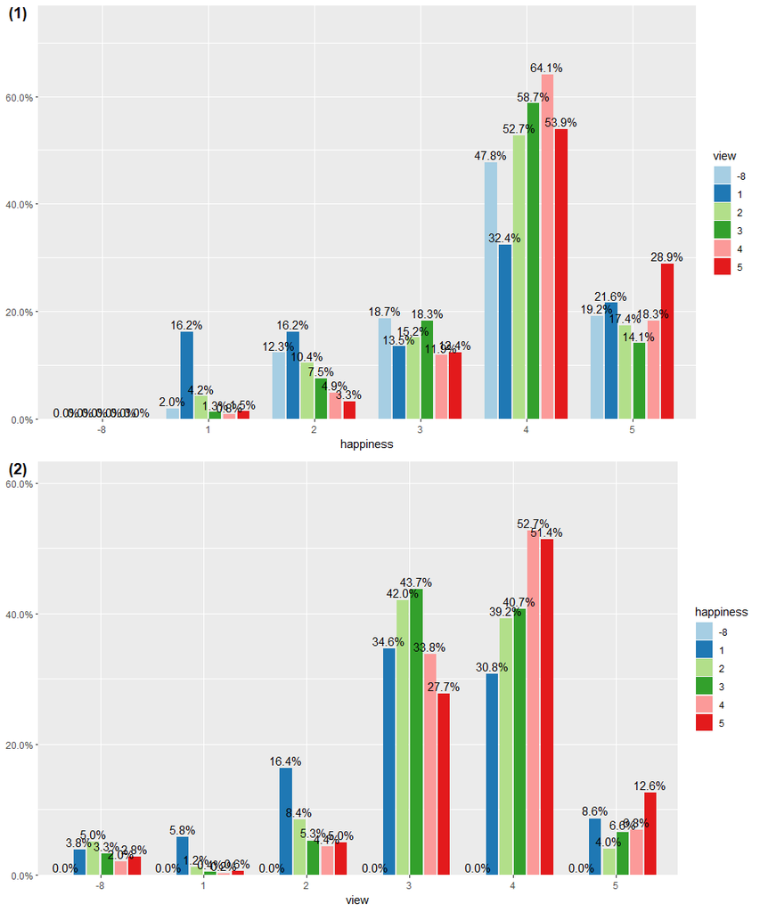

```r
#画图查看观点一致性与各幸福等级的占比
pic1 <- sjp.xtab(data$happiness,data$view,show.total = FALSE,show.prc = TRUE,show.n = FALSE)
pic2 <- sjp.xtab(data$view,data$happiness,show.total = FALSE,show.prc = TRUE,show.n = FALSE)

ggarrange(pic1,pic2,nrow=2,labels=c("(1)","(2)"))
```

- 如图(1)所示，比较幸福(happiness=4)并且与社会大众观点一致的时候比较多(view=4)的人数占比最多。不幸福(happiness<=2)的群体中，与社会观点基本不一致(view<=3)的人占主导，幸福(happiness>=4)的群体中，与社会观点基本一致(view>=4)的人占主导。
- 如图(2)所示，与社会观点基本不一致（view<=3）的群体中，感觉不幸福的人数占比会大于幸福的人数，与社会观点基本一致（view>=4）的群体中觉得幸福的人数占比会超过不幸福的人数。

# 6 **建立模型**

- **此部分主要参考谢颖.《R语言与社会科学调查数据分析》**

## 6.1 **多元线性回归模型**

- 流程：
  - 利用主成分分析法进行数据降维
  - 利用提取的主成分进行多元线性回归模型的建立
  - 回归模型的检验

### 6.1.1 **数据降维:主成分分析法PCA**

1. 数据标准化

```r
library(tidyverse)
data_original<-read.csv("data/happiness_train_clean.csv")
#取出data中后几列，并将数据标准化,统一量纲
data_new<-scale(data_original[,c(3:38)])
```

2. 数据相关性分析

```r
happy<-data_original[,c(3:38)]
library(psych)
corr.test(happy,use="complete")
```

```
Call:corr.test(x = happy, use = "complete")
Correlation matrix
                survey_type province gender nationality religion religion_freq   edu income political floor_area health
survey_type            1.00     0.09  -0.02        0.11    -0.01          0.01 -0.38  -0.06     -0.13       0.28  -0.11
province               0.09     1.00  -0.01       -0.10     0.03          0.01 -0.11  -0.01     -0.02       0.04  -0.03
gender                -0.02    -0.01   1.00       -0.01    -0.05          0.07 -0.11  -0.03     -0.13      -0.01  -0.08
nationality            0.11    -0.10  -0.01        1.00    -0.05          0.11 -0.07  -0.02     -0.02       0.13  -0.03
religion              -0.01     0.03  -0.05       -0.05     1.00         -0.13  0.05   0.01      0.03      -0.03   0.05
religion_freq          0.01     0.01   0.07        0.11    -0.13          1.00 -0.08  -0.01     -0.04       0.03  -0.03
edu                   -0.38    -0.11  -0.11       -0.07     0.05         -0.08  1.00   0.08      0.29      -0.11   0.25
income                -0.06    -0.01  -0.03       -0.02     0.01         -0.01  0.08   1.00      0.02      -0.01   0.04
political             -0.13    -0.02  -0.13       -0.02     0.03         -0.04  0.29   0.02      1.00      -0.03   0.06
floor_area             0.28     0.04  -0.01        0.13    -0.03          0.03 -0.11  -0.01     -0.03       1.00   0.05
health                -0.11    -0.03  -0.08       -0.03     0.05         -0.03  0.25   0.04      0.06       0.05   1.00
health_problem        -0.14    -0.03  -0.08        0.00     0.04         -0.04  0.24   0.03      0.07      -0.01   0.53
depression            -0.10    -0.06  -0.05       -0.02     0.02         -0.04  0.17   0.02      0.08       0.01   0.41
hukou                 -0.46    -0.08  -0.02       -0.08     0.02          0.00  0.32   0.04      0.15      -0.14   0.03
socialize              0.12     0.01   0.03        0.08    -0.01          0.02 -0.02   0.00      0.01       0.11   0.10
relax                 -0.10     0.04   0.01       -0.01    -0.02          0.01  0.10  -0.02      0.09      -0.02   0.04
learn                 -0.28    -0.09  -0.09       -0.03     0.00         -0.02  0.51   0.05      0.24      -0.07   0.22
equity                 0.06    -0.03  -0.02        0.03     0.01         -0.02 -0.01   0.00      0.04       0.03   0.04
class                 -0.08    -0.07   0.01       -0.05     0.02          0.00  0.17   0.04      0.09       0.07   0.17
work_exper             0.03     0.00   0.17        0.00    -0.03          0.04 -0.20  -0.06      0.02      -0.04  -0.21
work_status           -0.29    -0.03  -0.14       -0.06     0.05         -0.03  0.37   0.07      0.04      -0.05   0.26
work_yr               -0.27    -0.02  -0.16       -0.07     0.04         -0.02  0.28   0.06      0.07      -0.04   0.18
work_type             -0.30    -0.02  -0.14       -0.07     0.05         -0.03  0.37   0.08      0.04      -0.05   0.26
work_manage           -0.29    -0.02  -0.14       -0.07     0.05         -0.03  0.36   0.07      0.03      -0.05   0.26
family_income         -0.06    -0.01  -0.02       -0.02     0.01          0.00  0.11   0.10      0.03       0.01   0.06
family_m               0.10     0.02   0.00        0.08     0.00          0.01 -0.02   0.00     -0.06       0.23   0.10
family_status         -0.04    -0.02  -0.02       -0.04     0.03         -0.01  0.15   0.03      0.08       0.10   0.19
                health_problem depression hukou socialize relax learn equity class work_exper work_status work_yr
survey_type              -0.14      -0.10 -0.46      0.12 -0.10 -0.28   0.06 -0.08       0.03       -0.29   -0.27
province                 -0.03      -0.06 -0.08      0.01  0.04 -0.09  -0.03 -0.07       0.00       -0.03   -0.02
gender                   -0.08      -0.05 -0.02      0.03  0.01 -0.09  -0.02  0.01       0.17       -0.14   -0.16
nationality               0.00      -0.02 -0.08      0.08 -0.01 -0.03   0.03 -0.05       0.00       -0.06   -0.07
religion                  0.04       0.02  0.02     -0.01 -0.02  0.00   0.01  0.02      -0.03        0.05    0.04
religion_freq            -0.04      -0.04  0.00      0.02  0.01 -0.02  -0.02  0.00       0.04       -0.03   -0.02
edu                       0.24       0.17  0.32     -0.02  0.10  0.51  -0.01  0.17      -0.20        0.37    0.28
income                    0.03       0.02  0.04      0.00 -0.02  0.05   0.00  0.04      -0.06        0.07    0.06
political                 0.07       0.08  0.15      0.01  0.09  0.24   0.04  0.09       0.02        0.04    0.07
```

[output cut: 178 more lines]

```
relax                      1.00 0.76        1.00 0.05 0.09
learn                      0.04 0.00        1.00 0.00 1.00
equity                     1.00 0.00        1.00 0.00 1.00
class                      1.00 0.00        0.00 0.12 0.11
work_exper                 0.48 0.01        0.00 0.00 1.00
work_status                1.00 0.02        0.00 0.00 0.54
work_yr                    1.00 0.07        0.00 0.00 0.00
work_type                  1.00 0.01        0.00 0.00 0.48
work_manage                1.00 0.01        0.00 0.00 0.56
family_income              1.00 1.00        1.00 0.01 1.00
family_m                   1.00 1.00        1.00 0.00 1.00
family_status              0.02 0.00        0.65 0.00 1.00
 [ reached getOption("max.print") -- omitted 9 rows ]

 To see confidence intervals of the correlations, print with the short=FALSE option
```

[figure not shown]

```r
library(corrgram)
corrgram(happy,order=T,lower.panel = panel.shade,upper.panel = panel.shade,text.panel = panel.txt,main="pie")
```

- 相关系数图d额色彩越深，饱和度越高，变量相关性越大，我么可知这36个变量间存在相关性。
3. 判断主成分个数

```
Parallel analysis suggests that the number of factors =  11  and the number of components =  11
```

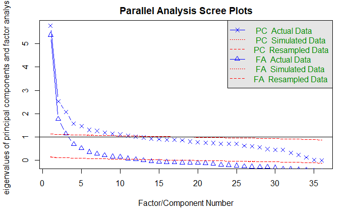

```r
library(psych)
fa.parallel(data_new,n.iter = 100)
```

```r
#n.iter 随机取n个数据矩阵推导出特征值均值(虚线),以及y=1的水平线
#选取特征根大于1的作为主成分
```

- 根据结果提取11个主成分
4. 提取主成分

```r
pc<-principal(data_new,nfactors = 11,rotate = "none")
pc
```

```
Principal Components Analysis
Call: principal(r = data_new, nfactors = 11, rotate = "none")
Standardized loadings (pattern matrix) based upon correlation matrix
```

|  | PC1 | PC2 | PC3 | PC4 | PC5 | PC6 | PC7 | PC8 | PC9 | PC10 | PC11 | h2 | u2 | com |
| --- | --- | --- | --- | --- | --- | --- | --- | --- | --- | --- | --- | --- | --- | --- |
| survey_type | -0.38 | -0.26 | 0.59 | 0.10 | 0.00 | 0.05 | -0.17 | -0.17 | -0.07 | 0.04 | 0.10 | 0.6434036 | 0.35659642 | 2.838740 |
| province | -0.07 | -0.13 | 0.10 | -0.02 | -0.04 | -0.11 | -0.21 | -0.28 | 0.51 | 0.12 | -0.05 | 0.4397813 | 0.56021871 | 2.569495 |
| gender | -0.20 | 0.01 | -0.01 | -0.08 | -0.16 | -0.16 | 0.40 | 0.32 | 0.25 | 0.40 | -0.12 | 0.6026523 | 0.39734771 | 5.186531 |
| nationality | -0.09 | -0.06 | 0.25 | 0.02 | -0.01 | 0.35 | 0.34 | -0.07 | -0.38 | -0.13 | 0.10 | 0.4894071 | 0.51059289 | 4.411931 |
| religion | 0.07 | 0.03 | 0.00 | -0.01 | 0.20 | -0.06 | -0.46 | 0.03 | 0.24 | 0.04 | -0.03 | 0.3153209 | 0.68467913 | 2.067089 |
| religion_freq | -0.07 | -0.05 | 0.03 | 0.06 | -0.18 | 0.15 | 0.51 | 0.04 | -0.11 | -0.01 | -0.03 | 0.3360386 | 0.66396137 | 1.656343 |
| edu | 0.57 | 0.43 | -0.21 | -0.26 | -0.06 | 0.16 | -0.10 | -0.02 | -0.12 | 0.10 | 0.03 | 0.6933753 | 0.30662474 | 3.155633 |
| income | 0.11 | 0.05 | -0.03 | 0.06 | -0.07 | 0.04 | -0.10 | 0.22 | 0.06 | -0.12 | 0.65 | 0.5211024 | 0.47889759 | 1.522004 |
| political | 0.14 | 0.35 | -0.23 | 0.07 | 0.00 | 0.26 | -0.22 | -0.26 | -0.16 | -0.14 | 0.03 | 0.4252593 | 0.57474067 | 6.044715 |
| floor_area | -0.06 | -0.02 | 0.54 | 0.15 | -0.25 | 0.20 | -0.03 | 0.01 | -0.02 | -0.12 | -0.06 | 0.4409088 | 0.55909117 | 2.085907 |

[output cut: 26 more lines]

```
                       PC1  PC2  PC3  PC4  PC5  PC6  PC7  PC8  PC9 PC10 PC11
SS loadings           5.76 2.52 2.06 1.57 1.47 1.31 1.26 1.19 1.15 1.11 1.06
Proportion Var        0.16 0.07 0.06 0.04 0.04 0.04 0.04 0.03 0.03 0.03 0.03
Cumulative Var        0.16 0.23 0.29 0.33 0.37 0.41 0.44 0.48 0.51 0.54 0.57
Proportion Explained  0.28 0.12 0.10 0.08 0.07 0.06 0.06 0.06 0.06 0.05 0.05
Cumulative Proportion 0.28 0.41 0.51 0.58 0.65 0.72 0.78 0.84 0.89 0.95 1.00

Mean item complexity =  3.6
Test of the hypothesis that 11 components are sufficient.

The root mean square of the residuals (RMSR) is  0.06
 with the empirical chi square  31153.03  with prob <  0

Fit based upon off diagonal values = 0.88
```

```r
#PC1为成分载荷(指观测变量与主成分的相关系数),若提取的主成分大于1,则会出现PC2、PC3等,成分载荷可以解释主成分与各变量的相关程度.
#h2栏为成分公因子方差,即主成分对每个变量的方差解释
#u2栏为成分唯一性,即方差无法被主成分解释的部分(1-h2) #SS loadings:公共因子对变量X的总方差贡献
#Proportion Var:方差贡献率
#Cumulative Var:累积方差贡献率
#Proportion Explained:按现有总解释方差百分比划分主成分
#Cumulative Proportion:累积百分比"
```

5. 主成分旋转
- 旋转是一系列将成分载荷阵变得更容易解释的数学方法,其中正交旋转是方差极大旋转,它试图对载荷阵的列进行去 噪,使得每个成分只是由一组有限的变量来解释(即载荷阵每列只有少数几个很大的载荷，其他 都是很小的载荷)。

```r
rc<-principal(data_new,nfactors = 11,rotate = "varimax")
rc
```

```
Principal Components Analysis
Call: principal(r = data_new, nfactors = 11, rotate = "varimax")
Standardized loadings (pattern matrix) based upon correlation matrix
```

|  | RC1 | RC3 | RC4 | RC6 | RC2 | RC5 | RC10 | RC8 | RC9 | RC7 | RC11 | h2 | u2 | com |
| --- | --- | --- | --- | --- | --- | --- | --- | --- | --- | --- | --- | --- | --- | --- |
| survey_type | -0.19 | -0.76 | 0.04 | -0.11 | 0.05 | -0.03 | 0.08 | 0.05 | 0.08 | 0.02 | -0.02 | 0.6434036 | 0.35659642 | 1.236517 |
| province | 0.03 | -0.20 | 0.05 | -0.08 | -0.15 | -0.03 | 0.04 | 0.35 | -0.13 | -0.47 | -0.06 | 0.4397813 | 0.56021871 | 2.904021 |
| gender | -0.14 | 0.10 | 0.06 | -0.05 | 0.05 | 0.03 | 0.01 | 0.05 | -0.74 | 0.09 | -0.04 | 0.6026523 | 0.39734771 | 1.197394 |
| nationality | -0.04 | -0.22 | -0.08 | -0.01 | 0.01 | 0.12 | 0.05 | 0.03 | 0.18 | 0.62 | 0.00 | 0.4894071 | 0.51059289 | 1.590385 |
| religion | 0.01 | -0.03 | -0.05 | 0.02 | 0.08 | 0.11 | 0.03 | -0.04 | 0.11 | -0.53 | 0.03 | 0.3153209 | 0.68467913 | 1.286654 |
| religion_freq | 0.01 | 0.04 | 0.09 | -0.04 | -0.05 | 0.01 | 0.07 | 0.10 | -0.19 | 0.52 | -0.04 | 0.3360386 | 0.66396137 | 1.529538 |
| edu | 0.22 | 0.51 | -0.55 | 0.11 | 0.14 | -0.08 | -0.01 | 0.06 | 0.16 | -0.03 | 0.11 | 0.6933753 | 0.30662474 | 2.920313 |
| income | 0.05 | 0.00 | 0.00 | 0.04 | -0.04 | 0.00 | 0.00 | -0.08 | 0.08 | -0.01 | 0.71 | 0.5211024 | 0.47889759 | 1.078152 |
| political | -0.05 | 0.30 | -0.14 | -0.04 | 0.12 | -0.07 | 0.00 | 0.16 | 0.51 | -0.01 | 0.05 | 0.4252593 | 0.57474067 | 2.304457 |
| floor_area | -0.02 | -0.40 | -0.05 | -0.02 | 0.09 | -0.12 | 0.47 | 0.07 | 0.06 | 0.17 | 0.00 | 0.4409088 | 0.55909117 | 2.609374 |

[output cut: 26 more lines]

```
                       RC1  RC3  RC4  RC6  RC2  RC5 RC10  RC8  RC9  RC7 RC11
SS loadings           4.75 2.32 2.06 1.98 1.52 1.45 1.44 1.28 1.27 1.26 1.14
Proportion Var        0.13 0.06 0.06 0.05 0.04 0.04 0.04 0.04 0.04 0.03 0.03
Cumulative Var        0.13 0.20 0.25 0.31 0.35 0.39 0.43 0.47 0.50 0.54 0.57
Proportion Explained  0.23 0.11 0.10 0.10 0.07 0.07 0.07 0.06 0.06 0.06 0.06
Cumulative Proportion 0.23 0.35 0.45 0.54 0.62 0.69 0.76 0.82 0.88 0.94 1.00

Mean item complexity =  1.8
Test of the hypothesis that 11 components are sufficient.

The root mean square of the residuals (RMSR) is  0.06
 with the empirical chi square  31153.03  with prob <  0

Fit based upon off diagonal values = 0.88
```

```r
library(psych)
unclass(rc$weights)
```